# Davidson & MacKinnon. Econometric Theory and Methods. (1999)

## Exercise 3.1.

### Generate a sample of size 25 from the model (3.11), with $\beta_1=1$ and $\beta_2=0.8$. For simplicity, assume that $y_0=0$ and that $u_t \sim iid\ N\left(0,1\right)$. Use this sample to compute the OLS estimates ${\hat{\beta}}_1$ and ${\hat{\beta}}_2$. Repeat at least 100 times, and find the averages of the ${\hat{\beta}}_1$ and ${\hat{\beta}}_2$. Use these averages to estimate the bias of the OLS estimators of $\beta_1$ and $\beta_2$. Repeat this exercise for sample sizes of 50, 100, and 200. What happens to the bias of $\beta_1$ and $\beta_2$ as the sample size is increased?

First, we'll generate a sample with size n = 25 for the model (3.11): $$y_t = \beta_1 \iota + \beta_2 y_{t-1} + u, u \sim iid(0, \sigma^2 I)$$ and define $\beta_1=1$ and $\beta_2=0.8$.

```r
#Model (3.11): y_t = \beta_1 \iota + \beta_2 y_{t-1} + u,  u ~ IID(0, \sigma^2 I)
sample_n = 25 #sample size
beta_1 = 1
beta_2 = 0.8
```

We'll perform a parametric bootstrap (assuming residuals normally-distributed with mean 0) with B = 200 simulations and define a empty vector of estimated $\hat\beta_1 \text{ and } \hat\beta_2$ that will be filled with their values on each simulation/loop.

```r
#Parametric Bootstrap - considering the residuals have normal distribution with mean 0
B = 200
betas_hat = data.frame("beta_1_hat"=as.double(), "beta_2_hat"=as.double()) #vector to input parametric bootstrapped betas
```

To do it, first, we'll sample a normal-distributed residual sample, assuming that $u_t \sim iid N(0,1)$. Then, considering $y_0=0$, we'll built a sample with $y_t \text{ and } y_{t-1}$ (lagged observation) based on the following model: $$y_t = \beta_1 \iota + \beta_2 y_{t-1} + u \ \ \ \ \ \ \ \ \ [\text{with } \beta_1=1 \text{ and } \beta_2=0.8]$$

Then, we'll perform a regression being $y_t$ the dependent variable, $\beta_1$ the intercept and $\beta_2$ the coefficient that multiplies the lagged independent variable $y_{t-1}$

```r
for (i in 1:B){
    residual = rnorm(sample_n, mean = 0, sd = 1)

    sample_data = data.frame("y"=as.double(), "y_1"=as.double()) #vector for y and y_1 (lagged)
    sample_data[1,2]=0 #y_0 = 0

    for (j in 1:sample_n){
      sample_data[j,1] = beta_1 + beta_2 *sample_data[j,2] + residual[j]
      sample_data[j+1,2] = sample_data[j,1]
    }

    reg_boot_p = lm(y ~ y_1, sample_data)
    coeff_boot_p = summary(reg_boot_p)$coefficients
    betas_hat[i,1] = coeff_boot_p["(Intercept)", "Estimate"]
    betas_hat[i,2] = coeff_boot_p["y_1", "Estimate"]
  }

  print(paste("Sample Size:", sample_n,
              " |  Beta 1 Hat:", round(mean(betas_hat$beta_1_hat),4),
              " |  Beta 1 Hat Bias:", round(mean(betas_hat$beta_1_hat-beta_1),4),
              " |  Beta 2 Hat:", round(mean(betas_hat$beta_2_hat),4),
              " |  Beta 2 Hat Bias:", round(mean(betas_hat$beta_2_hat-beta_2),4)))
```

```
[1] "Sample Size: 25  |  Beta 1 Hat: 1.3717  |  Beta 1 Hat Bias: 0.3717  |  Beta 2 Hat: 0.7126  |  Beta 2 Hat Bias: -0.0874"
```

```r
comparison = data.frame("sample_n"=as.integer(), "beta_1_hat"=as.double(), "beta_2_hat"=as.double(),
                        "beta_1_bias"=as.double(), "beta_2_bias"=as.double()) #vector to input parametric bootstrapped biases
for (sample_n in seq(from = 25, to = 400, by = 25)){
  #sample size
  #Model (3.11): y_t = \beta_1 \iota + \beta_2 y_{t-1} + u,  u ~ IID(0, \sigma^2 I)
  beta_1 = 1
  beta_2 = 0.8

  #Parametric Bootstrap - considering the residuals have normal distribution with mean 0
  B = 200
  betas_hat = data.frame("beta_1_hat"=as.double(), "beta_2_hat"=as.double()) #vector to input parametric bootstrapped betas

  for (i in 1:B){
    residual = rnorm(sample_n, mean = 0, sd = 1)

    sample_data = data.frame("y"=as.double(), "y_1"=as.double())
    sample_data[1,2]=0 #y_0 = 0

    for (j in 1:sample_n){
      sample_data[j,1] = beta_1 + beta_2 *sample_data[j,2] + residual[j]
      sample_data[j+1,2] = sample_data[j,1]
    }

    reg_boot_p = lm(y ~ y_1, sample_data)
    coeff_boot_p = summary(reg_boot_p)$coefficients
    betas_hat[i,1] = coeff_boot_p["(Intercept)", "Estimate"]
    betas_hat[i,2] = coeff_boot_p["y_1", "Estimate"]
  }

  comparison[nrow(comparison)+1, 1] = sample_n
  comparison[nrow(comparison), 2] = round(mean(betas_hat$beta_1_hat),4)
  comparison[nrow(comparison), 3] = round(mean(betas_hat$beta_2_hat),4)
  comparison[nrow(comparison), 4] = round(mean(betas_hat$beta_1_hat-beta_1),4)
  comparison[nrow(comparison), 5] = round(mean(betas_hat$beta_2_hat-beta_2),4)
}

print(comparison)
```

```
   sample_n beta_1_hat beta_2_hat beta_1_bias beta_2_bias
1        25     1.3698     0.7121      0.3698     -0.0879
2        50     1.2395     0.7473      0.2395     -0.0527
3        75     1.1526     0.7692      0.1526     -0.0308
4       100     1.1183     0.7754      0.1183     -0.0246
5       125     1.1284     0.7740      0.1284     -0.0260
6       150     1.1081     0.7786      0.1081     -0.0214
7       175     1.0640     0.7850      0.0640     -0.0150
8       200     1.0642     0.7882      0.0642     -0.0118
9       225     1.0651     0.7866      0.0651     -0.0134
10      250     1.0432     0.7928      0.0432     -0.0072
11      275     1.0595     0.7868      0.0595     -0.0132
12      300     1.0561     0.7888      0.0561     -0.0112
13      325     1.0587     0.7885      0.0587     -0.0115
14      350     1.0486     0.7888      0.0486     -0.0112
15      375     1.0291     0.7938      0.0291     -0.0062
16      400     1.0439     0.7912      0.0439     -0.0088
```

Note that, as the sample sizes increase, the intercept $\hat\beta_1$ and the slope $\hat\beta_2$ seem to converge to their real values $\beta_1=1$ and $\beta_1=0.8$, respectively. Therefore, their biases also seem to converge to zero, as we can see in the graphs below.

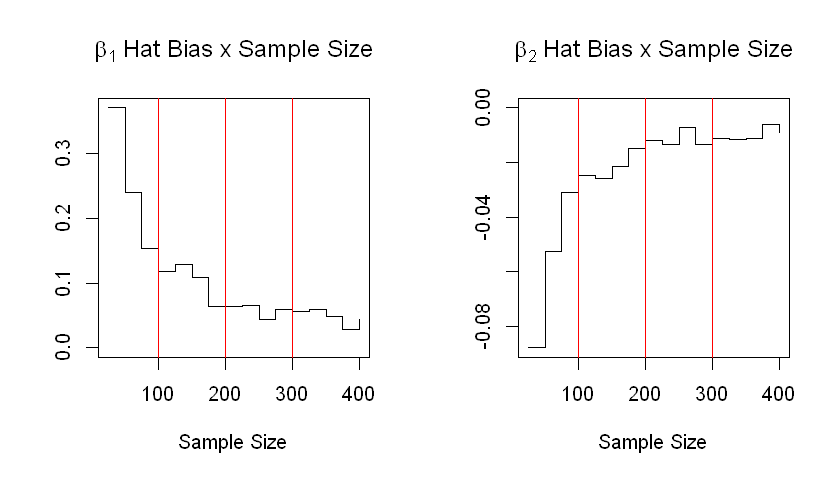

```r
options(repr.plot.width=7, repr.plot.height=4)
par(mfrow = c(1,2))
plot(cbind("Sample Size"=comparison$sample_n,comparison$beta_1_bias), type = "s",
     main=expression(beta[1]~"Hat Bias x Sample Size"), ylim=c(0,max(comparison$beta_1_bias)))
abline(v=c(100,200,300),col="red")

plot(cbind("Sample Size"=comparison$sample_n,comparison$beta_2_bias), type = "s",
     main=expression(beta[2]~"Hat Bias x Sample Size"), ylim=c(min(comparison$beta_2_bias),0))
abline(v=c(100,200,300),col="red")
```